Estadística Básica

[figure not shown]

# TP Nº 9: Análisis de Regresión y Correlación Lineal

# Ejercicios sugeridos

Para descargar los archivos hacer click sobre el nombre del archivo con el botón derecho, seleccionar **Guardar enlace como…** e indicar el directorio de trabajo.

```r
# Paquetes requeridos
library(rio)
library(tidyverse)
library(moments)
library(estadisticaFcaUnl)
```

## Ejercicio 1

Los siguientes datos representan la cantidad de agua aplicada (cm<sup>3</sup>) y el rendimiento de una especie forrajera (tn MS ha<sup>-1</sup>), en un establecimiento de la provincia de Santa Fe.

```
 agua   MS
   12 5.27
   18 5.68
   24 6.25
   30 7.53
   36 8.02
```

Los datos se encuentran en el archivo agua_forrajera.xlsx

1. Hacer un diagrama de dispersión ¿como es la relación entre las variables?
2. Hallar la recta de regresión del rendimiento en función del agua. Representar gráficamente. Interpretar los parámetros.
3. ¿Es estadísticamente significativo el coeficiente de regresión?
4. Interpretar la bondad de ajuste del modelo.
5. Estimar los intervalos de confianza de los parámetros del modelo.
6. Predecir cual será el rendimiento del forraje si se aplican 20 cm<sup>3</sup>.

### Respuestas

```r
# Opción 1: Importar archivo local
agua_forrajera <- import("agua_forrajera.xlsx")

# Opción 2: Cargar desde la librería de la cátedra
data(agua_forrajera)
```

1. Grafico de dispersión o Scatterplot

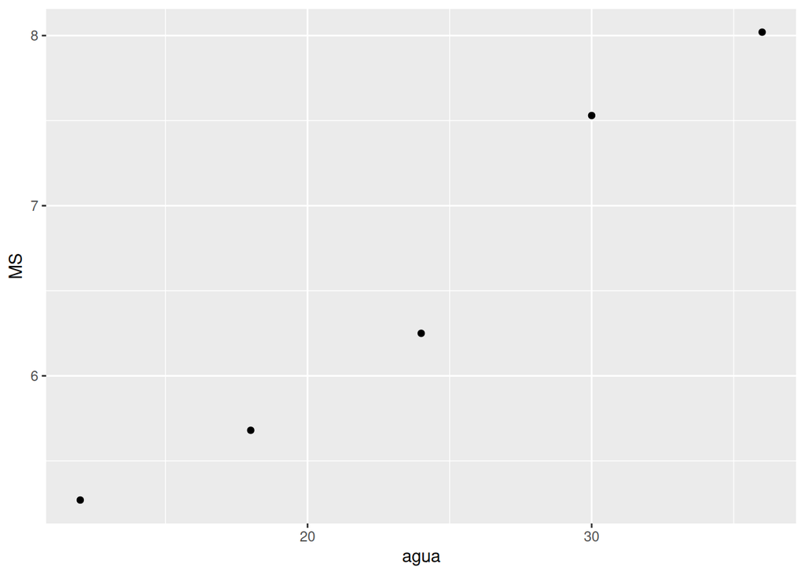

```r
ggplot(agua_forrajera, aes(agua, MS)) +
    geom_point()
```

2. Ajuste modelo lineal

```r
mod <- lm(MS ~ agua, agua_forrajera)
mod
```

```
Call:
lm(formula = MS ~ agua, data = agua_forrajera)

Coefficients:
(Intercept)         agua
     3.6100       0.1225
```

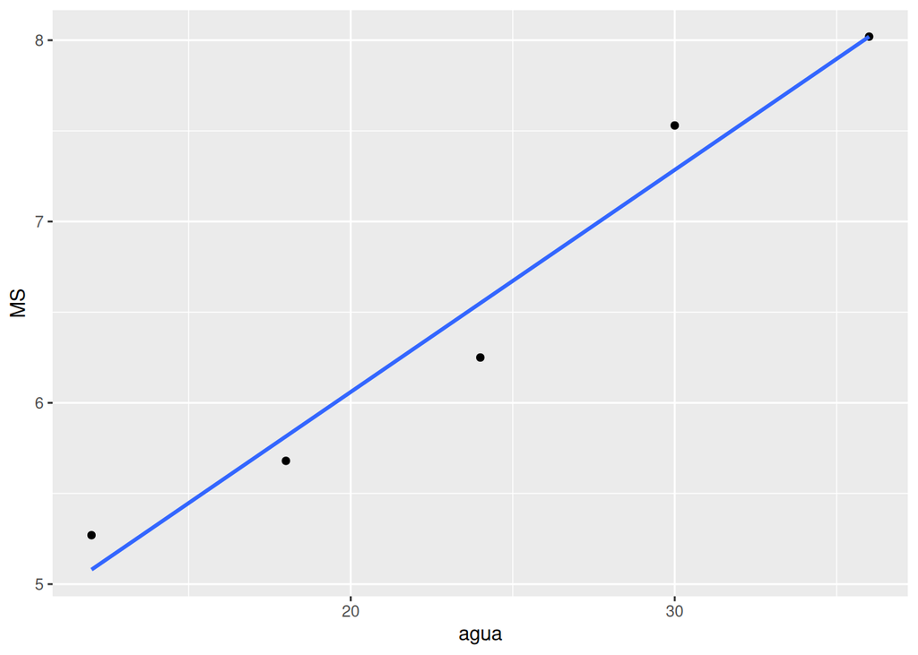

```r
# Agregar linea al grafico de dispersión
ggplot(agua_forrajera, aes(agua, MS)) +
    geom_point() +
    geom_smooth(
        method = lm, # Recta de regresión
        se = FALSE
    ) # Oculta intervalo de confianza
```

El modelo es: $MS = 3.61 +0.1225 \times agua$

3. Significancia de la regresión

```r
# Tabla de anova hipotesis sobre B1
anova(mod)
```

```
Analysis of Variance Table

Response: MS
          Df Sum Sq Mean Sq F value   Pr(>F)
agua       1 5.4023  5.4023  79.309 0.002986 **
Residuals  3 0.2043  0.0681
---
Signif. codes:  0 '***' 0.001 '**' 0.01 '*' 0.05 '.' 0.1 ' ' 1
```

```r
# O resumen modelo: hipotesis sobre B1 o Prueba F
summary(mod)
```

```
Call:
lm(formula = MS ~ agua, data = agua_forrajera)

Residuals:
         1          2          3          4          5
 1.900e-01 -1.350e-01 -3.000e-01  2.450e-01 -8.257e-16

Coefficients:
            Estimate Std. Error t value Pr(>|t|)
(Intercept)  3.61000    0.35016  10.310  0.00195 **
agua         0.12250    0.01376   8.906  0.00299 **
---
Signif. codes:  0 '***' 0.001 '**' 0.01 '*' 0.05 '.' 0.1 ' ' 1

Residual standard error: 0.261 on 3 degrees of freedom
Multiple R-squared:  0.9636,    Adjusted R-squared:  0.9514
F-statistic: 79.31 on 1 and 3 DF,  p-value: 0.002986
```

4. Bondad de ajuste: coeficiente de determinación de la tabla `summary()`

```r
# Coeficiente correlación
summary(mod)$r.squared
```

```
[1] 0.9635519
```

5. Intervalos de confianza

```r
confint(mod)
```

```
                 2.5 %   97.5 %
(Intercept) 2.49564381 4.724356
agua        0.07872395 0.166276
```

6. Predicción

```r
MS20 <- predict(mod, newdata = list(agua = 20))
MS20
```

```
   1
6.06
```

## Ejercicio 2

A continuación se detallan los datos de una muestra de 12 explotaciones agrícolas donde se registra el tamaño de las mismas y el área sembrada con trigo:

```
 sup_total sup_trigo
       147        56
       125        42
       160        72
       118        36
       149        63
       128        47
       150        55
       145        49
       115        38
       140        42
       152        68
       152        60
```

Los datos se encuentran en el archivo area_trigo.xlsx

1. Explorar gráficamente la relación entre la superficie total de la explotación y la superficie destinada al cultivo de trigo.
2. Calcular e interpretar el coeficiente de correlación.
3. Determinar si la correlación observada es estadísticamente significatvia 5%.

### Respuestas

```r
# Opción 1: Importar archivo local
area_trigo <- import("area_trigo.xlsx")

# Opción 2: Cargar desde la librería de la cátedra
data(area_trigo)
```

1. Grafico de dispersión: Scatterplot

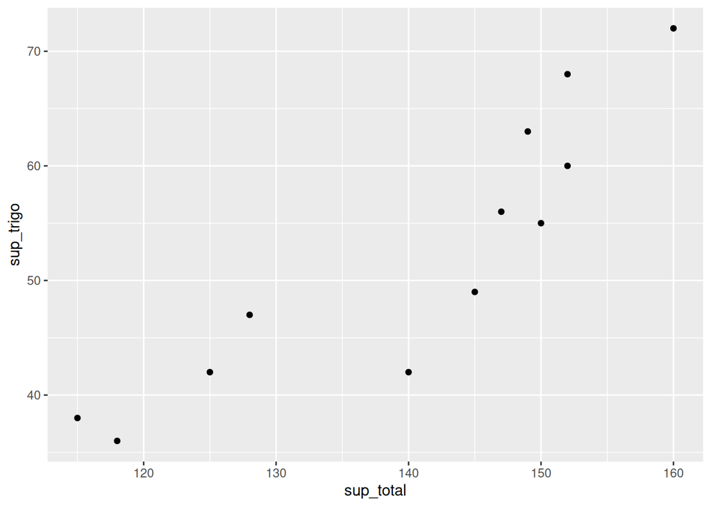

```r
ggplot(area_trigo, aes(sup_total, sup_trigo)) +
    geom_point()
```

2. Coeficiente de correlación

```r
with(area_trigo, cor(sup_total, sup_trigo))
```

```
[1] 0.8989093
```

3. Prueba de hipótesis
   $$H_0: \rho = 0
   \\ H_1: \rho \ne 0$$

```r
with(area_trigo, cor.test(sup_total, sup_trigo))
```

```
    Pearson's product-moment correlation

data:  sup_total and sup_trigo
t = 6.488, df = 10, p-value = 7.002e-05
alternative hypothesis: true correlation is not equal to 0
95 percent confidence interval:
 0.6713448 0.9715846
sample estimates:
      cor
0.8989093
```

*Se rechaza* $H_0$

## Ejercicio 3

Los siguientes datos proceden de un estudio de pérdida de agua en el coleóptero de la harina (*Tribolium confusum*). Se pesaron 9 lotes de 25 coleópteros cada uno, se guardaron a diferente humedad relativa y se pesaron nuevamente a los 6 días. Se calculó la pérdida de peso (mg) para cada lote:

```
   HR perdida
  0.0    8.98
 12.0    8.14
 29.5    6.67
 43.0    6.08
 53.0    5.90
 62.5    5.83
 75.5    4.68
 85.0    4.20
 93.0    3.72
```

Los datos se encuentran en el archivo coleoptero.xlsx

1. Hace un gráfico de dispersión. ¿como es la relación entre la humedad relativa y la pérdida de peso?
2. Obtener la recta de regresión lineal.
3. Determinar con un nivel de significancia del 5% si la pendiente de la recta es diferente de 0. ¿Qué representa este valor?
4. Estimar con un 95% de confianza los límites del intervalo que contiene a la verdadera tasa de peridad de peso.
5. Estimar con un 95% de confianza los límites del intervalo que contiene a la verdadera perdida de peso cuando la humedad relativa es 0%.
6. ¿Que propoción de variabilidad de la perdida de peso no es explicada por el modelo?

### Respuestas

```r
# Opción 1: Importar archivo local
coleoptero <- import("coleoptero.xlsx")

# Opción 2: Cargar desde la librería de la cátedra
data(coleoptero)
```

1. Gráfico de dispersión

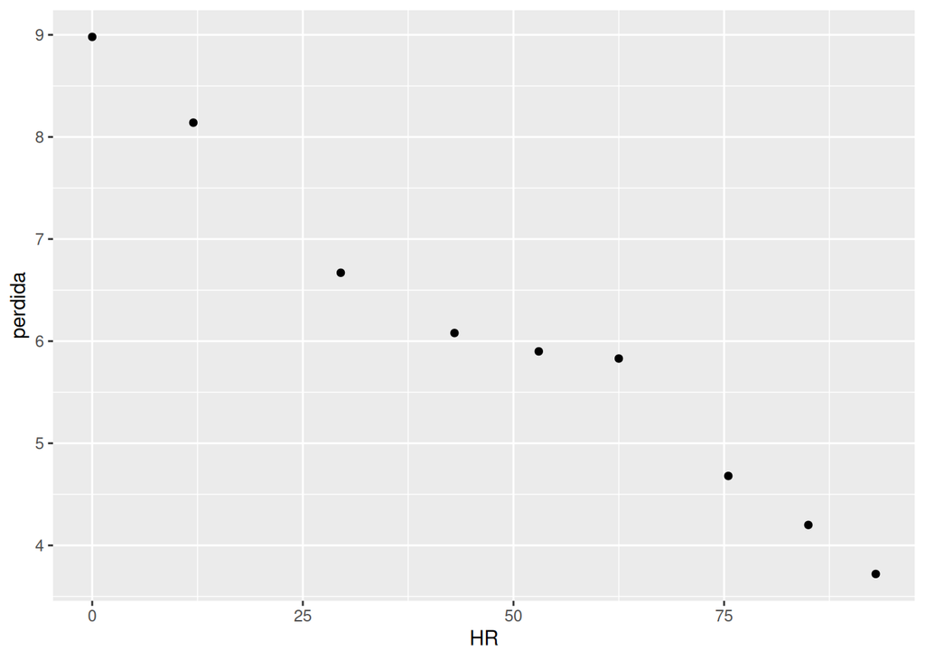

```r
ggplot(coleoptero, aes(HR, perdida)) +
    geom_point()
```

2. Modelo

```r
mod <- lm(perdida ~ HR, coleoptero)
mod
```

```
Call:
lm(formula = perdida ~ HR, data = coleoptero)

Coefficients:
(Intercept)           HR
    8.70403     -0.05322
```

3. Hipotesis
   $$H_0: \beta_1 = 0 \\ H_1:
   \beta_1 \ne 0$$

```r
summary(mod)
```

```
Call:
lm(formula = perdida ~ HR, data = coleoptero)

Residuals:
     Min       1Q   Median       3Q      Max
-0.46397 -0.03437  0.01675  0.07464  0.45236

Coefficients:
             Estimate Std. Error t value Pr(>|t|)
(Intercept)  8.704027   0.191565   45.44 6.54e-10 ***
HR          -0.053222   0.003256  -16.35 7.82e-07 ***
---
Signif. codes:  0 '***' 0.001 '**' 0.01 '*' 0.05 '.' 0.1 ' ' 1

Residual standard error: 0.2967 on 7 degrees of freedom
Multiple R-squared:  0.9745,    Adjusted R-squared:  0.9708
F-statistic: 267.2 on 1 and 7 DF,  p-value: 7.816e-07
```

*Existe evidencia significativa para rechazar* $H_0$ (P<0.0001), la regresión es significativa

4. y e. Intervalos de confianza B1

```r
confint(mod)
```

```
                  2.5 %      97.5 %
(Intercept)  8.25104923  9.15700538
HR          -0.06092143 -0.04552287
```

```r
1 - summary(mod)$r.squared
```

```
[1] 0.0255304
```

## Ejercicio 4

Se realizó un experimento para determinar la relación entre la cantidad de P inorgánico en el suelo (ppm) al inicio del cultivo de maiz y la cantidad de P que es recuperada por la planta (en ppm) a los 30 días. Para ello se prepararon macetas con distintas concentraciones de P inicial a las cuales se les sembró el mismo híbrido de maiz y luego de 30 días se determinó el contenido de P en planta. Los resultados fueron:

```
 P_suelo P_planta
     0.4       64
     3.1       71
     4.7       54
     9.4       81
    11.6       98
    10.9       76
    23.1       76
    23.1       95
    29.9       99
```

Los datos se encuentran en el archivo P_maiz.xlsx

1. Graficar la relación entre `P_suelo` y `P_planta`.
2. Asumiendo que el valor de P_suelo se mide sin error, estimar los parámetros de un modelo lineal que relacione ambas variables.
3. Estimar con un 95% de confianza el intervalo que contenga el aumento del `P_planta` por cada unidad de `P_suelo`.
4. Estimar el contenido de `P_planta` si en el suelo hay 20 ppm de fósforo.

### Respuestas

```r
# Opción 1: Importar archivo local
P_maiz <- import("P_maiz.xlsx")

# Opción 2: Cargar desde la librería de la cátedra
data(P_maiz)
```

1. Scatterplot

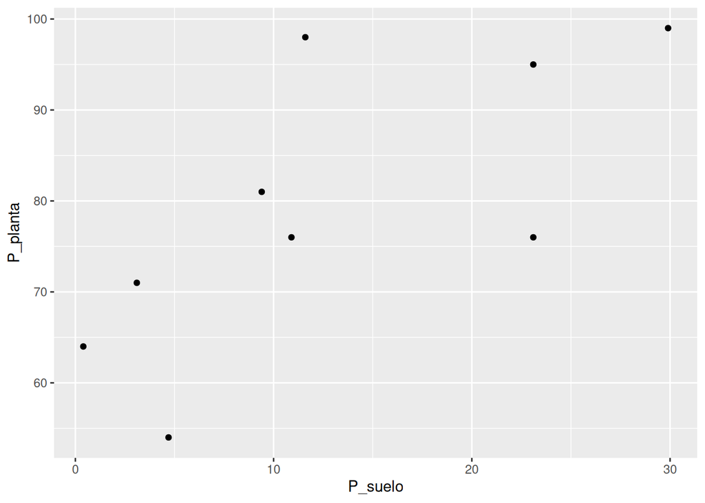

```r
ggplot(P_maiz, aes(P_suelo, P_planta)) +
    geom_point()
```

2. Modelo

```r
mod <- lm(P_planta ~ P_suelo, P_maiz)
mod
```

```
Call:
lm(formula = P_planta ~ P_suelo, data = P_maiz)

Coefficients:
(Intercept)      P_suelo
      65.13         1.10
```

3. IC

```r
confint(mod)
```

```
                 2.5 %    97.5 %
(Intercept) 49.8350608 80.434498
P_suelo      0.1498156  2.049616
```

4. Predicho

```r
predict(mod, newdata = list(P_suelo = 20))
```

```
      1
87.1291
```

## Ejercicio 5

Los siguientes datos representan el rendimiento en toneladas de forraje y la lluvia caída en mm, durante los meses de julio y agosto en 10 establecimientos elegidos al azar, en una determinada región.

```
 rend lluvia
    2      3
    1      6
    5      9
    3     12
    6     15
    4     18
    8     21
    9     24
   10     27
    7     30
```

Los datos se encuentran en el archivo lluvia_forraje.xlsx

1. Grafique la relación entre ambas variables.
2. ¿Se podría postular que la lluvia caida durante los meses de julio y agosto tiene una relación lineal con la producción de forraje?
3. Con un 95% de confianza, ¿entre que valores se encuentra la tasa de producción de pasto por milímetro de lluvia caido?
4. Si la lluvia caída fue de 20 mm, predecir cuál será el rendimiento de forraje.

### Respuestas

```r
# Opción 1: Importar archivo local
lluvia_forraje <- import("lluvia_forraje.xlsx")

# Opción 2: Cargar desde la librería de la cátedra
data(lluvia_forraje)
```

1. Dispersión

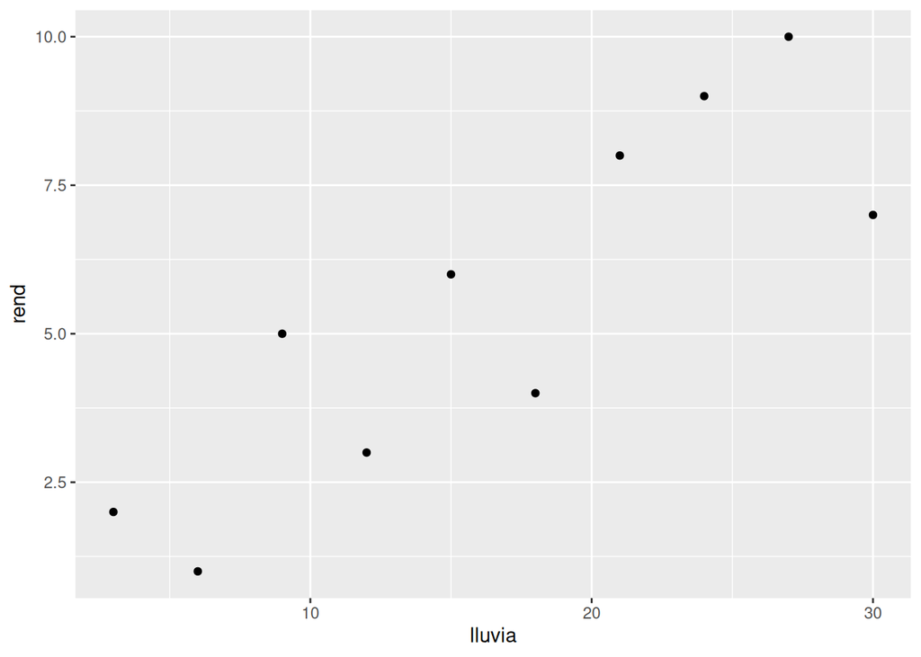

```r
ggplot(lluvia_forraje, aes(lluvia, rend)) +
    geom_point()
```

2. Modelo de regresión
   $$H_0: \beta_1 = 0
   \\ H_1: \beta_1 \ne 0$$

```r
mod <- lm(rend ~ lluvia, lluvia_forraje)
anova(mod)
```

```
Analysis of Variance Table

Response: rend
          Df Sum Sq Mean Sq F value   Pr(>F)
lluvia     1 60.245  60.245  21.657 0.001637 **
Residuals  8 22.255   2.782
---
Signif. codes:  0 '***' 0.001 '**' 0.01 '*' 0.05 '.' 0.1 ' ' 1
```

3. IC

```r
confint(mod)
```

```
               2.5 %   97.5 %
(Intercept) -1.82741 3.427410
lluvia       0.14370 0.425997
```

4. Predicción

```r
predict(mod, newdata = list(lluvia = 20))
```

```
      1
6.49697
```

## Ejercicio 6

Un estudio sobre maiz busca determinar la relación entre el peso de la espiga y el número de hileras de grano.

```
 Hileras Peso
       8  131
       8  132
       8  105
      10  194
      10  142
      10  111
      10  116
      10  146
      12  118
      12  100
      12  178
      12  138
      14  209
      14  205
      14  234
      14  176
      16  150
      16  168
```

Los datos se encuentran en el archivo hileras_maiz.xlsx

1. Estime el coeficiente de correlación entre las variables.
2. Estime los parámetros del modelo, y sus intervalos de confianza 95%
3. Mediante el ANOVA pruebe si la pendiente es significativa.

### Respuestas

```r
# Opción 1: Importar archivo local
hileras_maiz <- import("hileras_maiz.xlsx")

# Opción 2: Cargar desde la librería de la cátedra
data(hileras_maiz)
```

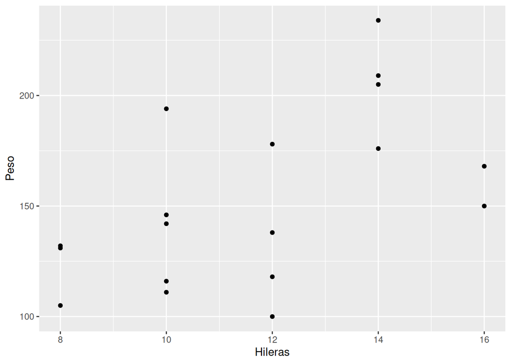

```r
ggplot(hileras_maiz, aes(Hileras, Peso)) +
    geom_point()
```

```r
with(hileras_maiz, cor(Hileras, Peso))
```

```
[1] 0.5477066
```

La correlación entre los datos es moderada.

2. Modelo

```r
mod <- lm(Peso ~ Hileras, hileras_maiz)
mod
```

```
Call:
lm(formula = Peso ~ Hileras, data = hileras_maiz)

Coefficients:
(Intercept)      Hileras
     55.961        8.313
```

```r
confint(mod)
```

```
                 2.5 %    97.5 %
(Intercept) -24.361335 136.28336
Hileras       1.582888  15.04284
```

3. Test sobre $\beta_1$

$$H_0: \beta_1 = 0 \\ H_1: \beta_1 \ne 0$$

```r
anova(mod)
```

```
Analysis of Variance Table

Response: Peso
          Df  Sum Sq Mean Sq F value  Pr(>F)
Hileras    1  7877.8  7877.8  6.8566 0.01863 *
Residuals 16 18383.1  1148.9
---
Signif. codes:  0 '***' 0.001 '**' 0.01 '*' 0.05 '.' 0.1 ' ' 1
```

## Ejercicio 7

La siguiente tabla detalla las calificaciones en Física y Matemática de una muestra de 12 alumnos

```
 Fisica Matematica
     65         68
     73         76
     87         88
     64         65
     78         79
     92         96
     70         78
     66         65
     88         81
     87         87
     79         78
     71         70
```

Los datos se encuentran en el archivo calificaciones.xlsx

1. Explorar la relación entre las variables mediante un gráfico.
2. Calcular e interpretar el coeficiente de correlación lineal.
3. Verificar si existe correlación estidisticamente significativa entre las calificaciones.

### Respuestas

```r
# Opción 1: Importar archivo local
calificaciones <- import("calificaciones.xlsx")

# Opción 2: Cargar desde la librería de la cátedra
data(calificaciones)
```

1. scatterplot

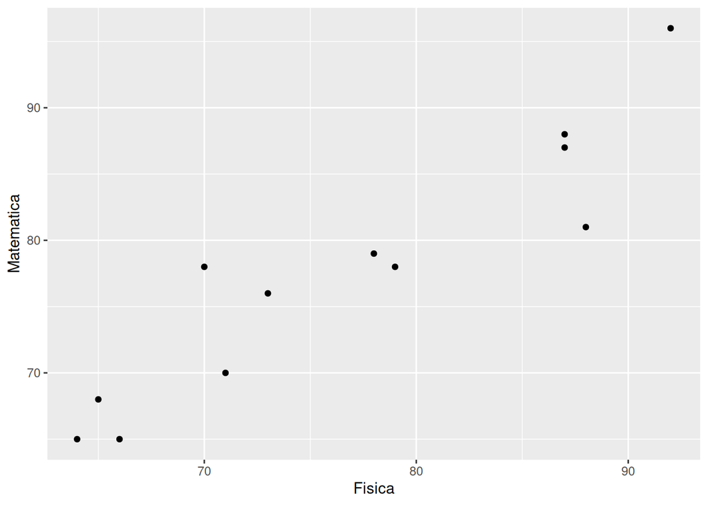

```r
ggplot(calificaciones, aes(Fisica, Matematica)) +
    geom_point()
```

2. Coeficiente de correlación

```r
with(calificaciones, cor(Fisica, Matematica))
```

```
[1] 0.932516
```

3. Prueba hipotesis
   $$H_0: \rho = 0 \\ H_1:
   \rho \ne 0$$

```r
with(calificaciones, cor.test(Fisica, Matematica))
```

```
    Pearson's product-moment correlation

data:  Fisica and Matematica
t = 8.1657, df = 10, p-value = 9.835e-06
alternative hypothesis: true correlation is not equal to 0
95 percent confidence interval:
 0.7714998 0.9812693
sample estimates:
     cor
0.932516
```

Existen evidencias suficientes para rechazar $H_0$, por lo tanto la correlación entre las notas de matemática y física es significativa (P = 9.835e-6)

## Ejercicio 8

Con el objeto de indentificar variables asociadas con las diferencias de peso de semillas de trigo diploide (*Triticum monococcum*), Jing et al. (2007) estudiaron varios caracteres de (peso, longitud, diámetro, dureza) de 190 semillas obtenidas a azar.

Los datos se encuentran en el archivo semilla_trigo.xlsx

¿Existe asociación entre el peso y la longitud de la semilla? ¿Y entre el peso y la dureza del endosperma? Interprete el resultado de la prueba de hipótesis y la magnitud de la correlación obtenida.

### Respuestas

```r
# Opción 1: Importar archivo local
semilla_trigo <- import("semilla_trigo.xlsx")

# Opción 2: Cargar desde la librería de la cátedra
data(semilla_trigo)
```

```r
# Matriz de correlación
cor(semilla_trigo)
```

```
                  ID        Peso        Long    Diametro     Humedad
ID        1.00000000  0.04610033  0.03020719  0.02970574  0.07550890
Peso      0.04610033  1.00000000  0.88267427  0.88716055 -0.06266832
Long      0.03020719  0.88267427  1.00000000  0.99906586 -0.02345996
Diametro  0.02970574  0.88716055  0.99906586  1.00000000 -0.02056908
Humedad   0.07550890 -0.06266832 -0.02345996 -0.02056908  1.00000000
Dureza   -0.05442887 -0.20709007 -0.12425999 -0.12423886 -0.11157947
              Dureza
ID       -0.05442887
Peso     -0.20709007
Long     -0.12425999
Diametro -0.12423886
Humedad  -0.11157947
Dureza    1.00000000
```

Prueba hipotesis

$$H_0: \rho = 0 \\ H_1: \rho \ne
0$$

```r
cor.test(semilla_trigo$Peso, semilla_trigo$Long)
```

```
    Pearson's product-moment correlation

data:  semilla_trigo$Peso and semilla_trigo$Long
t = 25.751, df = 188, p-value < 2.2e-16
alternative hypothesis: true correlation is not equal to 0
95 percent confidence interval:
 0.8467116 0.9106082
sample estimates:
      cor
0.8826743
```

Existen evidencias suficientes para rechazar $H_0$, la correlación entre Peso y Longitud de la semilla es significativa (p<0.0001). El coeficiente de correlación ($r$ 0.8826) indica que la correlación es positiva y alta entre las variables mencionadas. Es decir, a medida que aumenta la longitud de la semilla, aumenta el peso de la semilla, o vice versa.

```r
cor.test(semilla_trigo$Peso, semilla_trigo$Dureza)
```

```
    Pearson's product-moment correlation

data:  semilla_trigo$Peso and semilla_trigo$Dureza
t = -2.9024, df = 188, p-value = 0.004146
alternative hypothesis: true correlation is not equal to 0
95 percent confidence interval:
 -0.33943682 -0.06670315
sample estimates:
       cor
-0.2070901
```

Existen evidencias suficientes para rechazar $H_0$, la correlación entre Peso y Dureza del endosperma es significativa (p=0.004). El coeficiente de correlación ($r$ -0.207) indica que la correlación es negativa y muy baja entre las variables mencionadas.

## Ejercicio 9

En un estudio sobre el éxito reproductivo de langostas, un entomólogo busca ajustar modelar la relación entre el peso de las hembras y el número de huevos que produce. Para ello selecciona 30 langostas de de diferentes pesos (en gramos) y registra el número de huevos que producen.

Los datos se encuentran en el archivo huevos.xlsx

1. Grafique los datos
2. Calcule e interprete el coeficiente de correlación de estos datos.
3. ¿Qué proporción de variación del número de huevos explicaría el modelo lineal en función del peso de las langostas?

### Respuestas

```r
# Opción 1: Importar archivo local
huevos <- import("huevos.xlsx")

# Opción 2: Cargar desde la librería de la cátedra
data(huevos)
```

1. Scatterplot

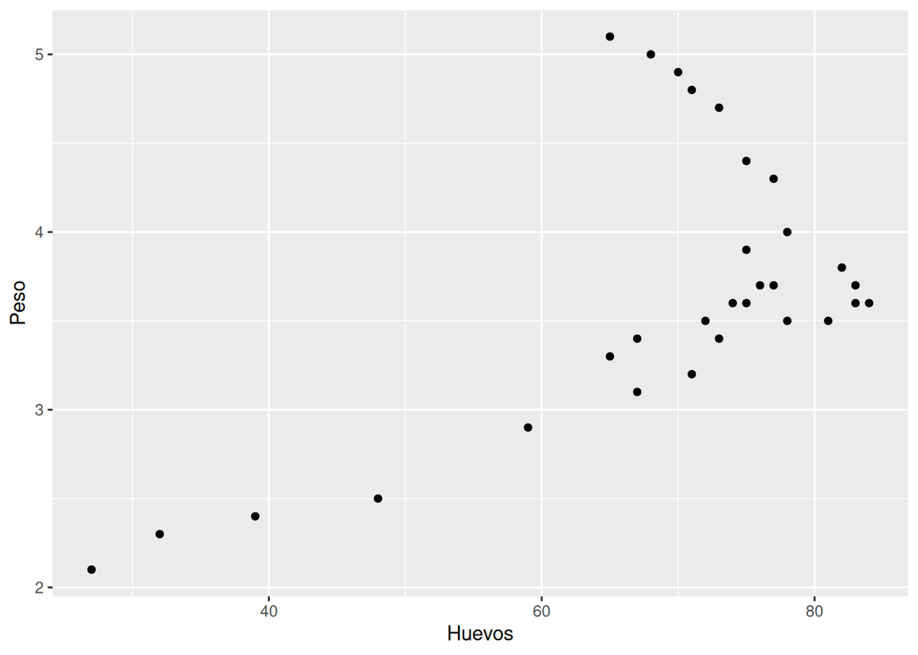

```r
ggplot(huevos, aes(Huevos, Peso)) +
    geom_point()
```

2. Correlación entre los datos

```r
cor(huevos$Huevos, huevos$Peso)
```

```
[1] 0.6058657
```

El coeficiente de correlación de estos datos es $r$ = 0.6058, es un valor medio y positivo pero si lo comparamos con la grafica vemos que la relación entre las variables no es lineal.

```r
mod <- lm(Huevos ~ Peso, huevos)
summary(mod)
```

```
Call:
lm(formula = Huevos ~ Peso, data = huevos)

Residuals:
    Min      1Q  Median      3Q     Max
-24.406  -7.837   3.853   7.164  15.729

Coefficients:
            Estimate Std. Error t value Pr(>|t|)
(Intercept)    27.80      10.41   2.671 0.012450 *
Peso           11.24       2.79   4.030 0.000388 ***
---
Signif. codes:  0 '***' 0.001 '**' 0.01 '*' 0.05 '.' 0.1 ' ' 1

Residual standard error: 11.71 on 28 degrees of freedom
Multiple R-squared:  0.3671,    Adjusted R-squared:  0.3445
F-statistic: 16.24 on 1 and 28 DF,  p-value: 0.000388
```

La proporción de variación del número de huevos que explicaría el modelo lineal en función del peso de las langostas es de 36.71% ($R^2$)

## Ejercicio 10

Un investigador condujo un experimento para modelar la relación entre la ganancia de peso en pollos cuyas dietas fueron suplementadas con distintas cantidades de lisina (aminoácido) y la cantidad de lisina consumida. Dado que el porcentaje de lisina del alimento es conocido, la cantidad de lisina consumida se estima a partir de la cantidad de alimento consumida. Se seleccionó una muestra aleatoria de 12 pollos los cuales fueron alojados en jaulas individuales y alimentados a voluntad con el alimento más el suplemento.

```
 ganancia lisina
     14.7   0.09
     17.8   0.14
     19.6   0.18
     18.4   0.15
     20.5   0.16
     21.1   0.23
     17.2   0.11
     18.7   0.19
     20.2   0.23
     16.0   0.13
     17.8   0.17
     19.4   0.21
```

Los datos se encuentran en el archivo pollos.xlsx

1. Grafique los datos
2. Estime los parámtros del modelo lineal.
3. ¿Qué proporción de la variación de la ganancia de peso es explicada por modelo en función de la lisina?
4. Si un pollo consumiera 0.20 g de lisina, ¿cual es el aumento de peso esperado? Estime con un 95% de confianza el intervalo de predicción para dicho aumento de peso.

### Respuestas

```r
# Opción 1: Importar archivo local
pollos <- import("pollos.xlsx")

# Opción 2: Cargar desde la librería de la cátedra
data(pollos)
```

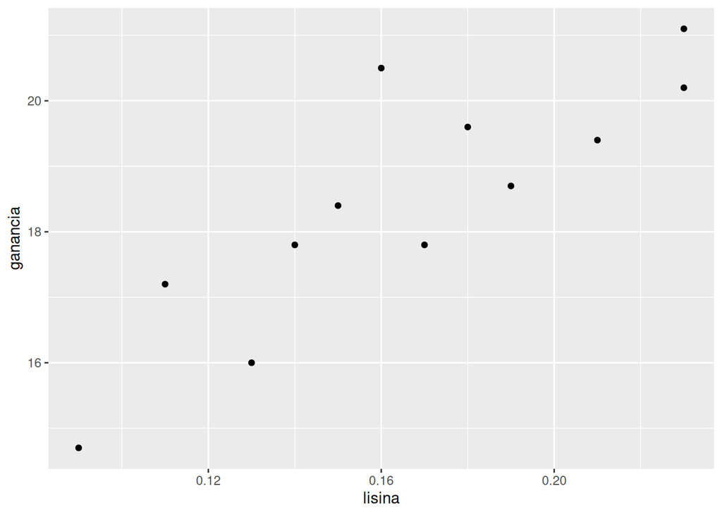

```r
ggplot(pollos, aes(lisina, ganancia)) +
    geom_point()
```

```r
mod <- lm(ganancia ~ lisina, pollos)
mod
```

```
Call:
lm(formula = ganancia ~ lisina, data = pollos)

Coefficients:
(Intercept)       lisina
      12.51        35.83
```

```r
summary(mod)
```

```
Call:
lm(formula = ganancia ~ lisina, data = pollos)

Residuals:
    Min      1Q  Median      3Q     Max
-1.1662 -0.6741 -0.1367  0.5486  2.2590

Coefficients:
            Estimate Std. Error t value Pr(>|t|)
(Intercept)   12.509      1.192   10.50 1.02e-06 ***
lisina        35.828      6.957    5.15 0.000431 ***
---
Signif. codes:  0 '***' 0.001 '**' 0.01 '*' 0.05 '.' 0.1 ' ' 1

Residual standard error: 1.034 on 10 degrees of freedom
Multiple R-squared:  0.7262,    Adjusted R-squared:  0.6988
F-statistic: 26.52 on 1 and 10 DF,  p-value: 0.0004315
```

La proporción de la variación de la ganancia de peso es explicada por modelo en función de la lisina es de $R^2 = 72.62\%$

```r
predict(mod, newdata = list(lisina = 0.20), interval = "prediction", level = 0.95)
```

```
       fit     lwr      upr
1 19.67412 17.2183 22.12995
```

Si un pollo consumiera 0.20 g de lisina, el aumento de peso esperado sería 19.67 gramos. El intervalo de predicción (95% de confianza) para dicho aumento de peso es de 17.2183 a 22.1299 gramos.

## Ejercicio 11

Se desea probar la efectividad de un nuevo fungicida para el control de roya en trigo. Se probaron distintas dosis en gramos de principio activo por ha (gr.p.a./ha) en 13 parcelas de 100 plantas cada una. A los 15 días de la aplicación se realizó una evaluación del daño, como el tamaño promedio de las machas en hoja bandera.

```
 Dosis Daño
   100   50
   125   48
   150   45
   175   39
   200   35
   225   30
   250   27
   275   25
   300   20
   325   17
   350   12
   375   10
   400    5
```

Los datos se encuentran en el archivo fungicida.xlsx

1. Estime los parámetros del un modelo de regresión lineal.
2. Pruebe la significancia de la pendiente e interprete. Utilice $\alpha=0.05$. Calcule su intervalo de confianza del 95%.
3. Interprete la bondad de ajuste del modelo.
4. Estime e interprete el coeficiente que mide la relación entre las variables.
5. Predecir el daño (tamaño promedio de las manchas) que se hallará si se aplican 260 gr.p.a./ha

### Respuestas

```r
# Opción 1: Importar archivo local
fungicida <- import("fungicida.xlsx")

# Opción 2: Cargar desde la librería de la cátedra
data(fungicida)
```

```r
mod <- lm(Daño ~ Dosis, fungicida)
mod
```

```
Call:
lm(formula = Daño ~ Dosis, data = fungicida)

Coefficients:
(Intercept)        Dosis
    66.0000      -0.1523
```

```r
summary(mod)
```

```
Call:
lm(formula = Daño ~ Dosis, data = fungicida)

Residuals:
    Min      1Q  Median      3Q     Max
-1.7308 -0.6923 -0.3077  0.8846  1.8461

Coefficients:
             Estimate Std. Error t value Pr(>|t|)
(Intercept) 66.000000   0.833227   79.21  < 2e-16 ***
Dosis       -0.152308   0.003122  -48.79 3.29e-14 ***
---
Signif. codes:  0 '***' 0.001 '**' 0.01 '*' 0.05 '.' 0.1 ' ' 1

Residual standard error: 1.053 on 11 degrees of freedom
Multiple R-squared:  0.9954,    Adjusted R-squared:  0.995
F-statistic:  2381 on 1 and 11 DF,  p-value: 3.289e-14
```

```r
confint(mod)
```

```
                 2.5 %     97.5 %
(Intercept) 64.1660797 67.8339203
Dosis       -0.1591782 -0.1454372
```

```r
summary(mod)$r.squared
```

```
[1] 0.9954007
```

La bondad de ajuste o $R²$ es 0.9954, es muy buen ajuste es decir que el 99.54% de la variación del tamaño promedio de las machas en hoja bandera es explicado por el modelo lineal en función de la dosis de fungicida.

```r
with(fungicida, cor(Daño, Dosis))
```

```
[1] -0.9976977
```

El coeficiente de correlación de estos datos ($r$) es -0.9976, lo cual indica un relación inversa y alta entre las variables estudiadas, es decir que a medida que aumento la dosis de fungicida el tamaño promedio de manchas en la hoja bandera, disminuye.

```r
predict(mod, newdata = list(Dosis = 260))
```

```
   1
26.4
```

El daño (tamaño promedio de las manchas) que se hallará si se aplican 260 gr.p.a./ha es de 26.4.

## Ejercicio 12

Los datos se refieren al contenido de proteína bruta (PB) y caseína (CA) en leche en una muestra de 23 tambos de la cuenca lechera del centro del país.

```
   PB   CA
 2.74 1.87
 3.19 2.26
 2.96 2.07
 2.91 2.09
 3.23 2.28
 3.04 2.04
 3.08 2.18
 3.23 2.30
 3.11 2.17
 3.11 2.15
 3.10 2.16
 3.25 2.33
 2.95 2.04
 3.08 2.16
 3.14 2.16
 3.22 2.22
 3.14 2.22
 3.15 2.24
 3.20 2.22
 2.95 2.07
 3.19 2.25
 3.12 2.23
 2.99 2.16
```

Los datos se encuentran en el archivo proteina_caseina.xlsx

Indique y pruebe la significancia de la relación entre las variables. Utilice $\alpha=0.05$.

### Respuestas

```r
# Opción 1: Importar archivo local
proteina_caseina <- import("proteina_caseina.xlsx")

# Opción 2: Cargar desde la librería de la cátedra
data(proteina_caseina)
```

$$H_0: \rho = 0 \\ H_1: \rho \ne
0$$

```r
with(proteina_caseina, cor.test(PB, CA))
```

```
    Pearson's product-moment correlation

data:  PB and CA
t = 12.022, df = 21, p-value = 7.045e-11
alternative hypothesis: true correlation is not equal to 0
95 percent confidence interval:
 0.8493513 0.9721675
sample estimates:
      cor
0.9344118
```

Existen evidencias suficientes para rechazar la $H_0$ (p<0.0001) por lo que la correlación lineal entre la proteina bruta y la caseina de la leche es significativa. Además el coeficiente de correlación de estas variables ($r$ = 0.9344) es alto y positivo, es decir que cuando encontramos alto contenido de proteína bruta tambien encontraremos alto contenido de caseina en la leche.

## Ejercicio 13

Se realizó un análisis de crecimiento de tomate en invernadero y se midieron distintas variables como rendimiento de fruto en kg/ha y la cantidad de tallos por m<sup>2</sup>.

Las plantas fueron establecidas en macetas, se utilizó un sistema de riego dirigido y se les aplicó diferentes dosis de fertilizante. Al momento de cosecha se contabilizaron los tallos y se pesaron los frutos.

Los datos se encuentran en el archivo dosis_tomate.xlsx

Se desea determinar el grado de correlación existente entre los diferentes órganos de la planta evaluados (fruto y tallos) y la ecuación que represente la relación entre el nivel de fertilizante utilizado y el rendimiento del fruto.

Las Variables estudiadas fueron la **dosis** de fertilizante (en ml/ha), rendimiento de **fruto** (en miles de kg/ha de peso húmedo) y **tallo** (número de tallos por m<sup>2</sup>).

**Responda:**

1. Interprete el coeficiente que *relaciona* los diferentes órganos de planta evaluados.
2. Pruebe la significancia estadística del coeficiente anterior. Utilice un nivel de significancia del 0.01.
3. Indique el modelo que mejor representa la relación entre el nivel de fertilizante utilizado y el rendimiento del fruto. *Interprete* los coeficientes del modelo.
4. Pruebe las hipótesis sobre el *coeficiente de regresión* y redacte una conclusión completa sobre la significancia estadística del modelo ajustado. Utilice un nivel de signficancia de 0.05.
5. Interprete el IC95% y el IC99% de los *parámetros* relevantes.
6. *Valore la bondad de ajuste* del modelo.
7. Si se desea aplicar una dosis de fertilizante de 25 ml/ha:
   1. Cuál es la respuesta promedio esperada de las plantas a las que se le aplique esa dosis de fertilizante con un 99% de confianza?
   2. Que rendimiento en fruto se espera obtener con esa dosis de fertilizante?
   3. Cuál es el intervalo de confianza de predicción del 99%, para la predicción anterior?